# Reference bias and iterative mapping — key findings from the chr19 simulations

gwct

10/28/2026 12:15 EDT

```r
# Render from the project root (all paths below are relative to it):
#   conda run -n renv Rscript -e 'rmarkdown::render("analyses/synthesis/brief.rmd", knit_root_dir = getwd())'
knitr::opts_chunk$set(echo = TRUE, warning = FALSE, message = FALSE, fig.align = "center")
library(ggplot2); library(dplyr); library(tidyr); library(readr); library(ggalluvial)
source("analyses/lib/design.r")

# --- callers: order and the display names used in every facet strip --------------------------
callers <- c("gatk", "bcftools", "freebayes")
caller_names <- c(gatk = "GATK HaplotypeCaller", bcftools = "bcftools", freebayes = "freebayes")
fac <- function(x) factor(caller_names[x], levels = caller_names)
pct <- scales::percent

# --- input tables (all already produced by the section pipelines s01-s08) ---------------------
S01_SUMMARY  <- "analyses/s01-baseline-iterative/results/s01-base-iterative-summary.csv"
S02_SUMMARY  <- "analyses/s02-indels/results/s02-indels-recovery-summary.csv"
S05_SNP      <- "analyses/s05-heterogeneous-divergence/results/s05-realistic-meansweep-iterative-summary.csv"
S05_INDEL    <- "analyses/s05-heterogeneous-divergence/results/s05-realistic-meansweep-indels-recovery-summary.csv"
S05_LOCAL    <- "analyses/s05-heterogeneous-divergence/results/s05-realistic-local-recall.csv"
S05_MVC      <- "analyses/s05-heterogeneous-divergence/results/s05-mapping-vs-calling-capped.csv"
S02_GTRAJ    <- "analyses/s02-indels/results/vrf-agg/vrf-agg-gatk-0.10-gtraj.csv"
S06_SWEEP    <- "analyses/s06-filtering/results/s06-filter-sweep.csv"
S07_SV       <- "analyses/s07-svs/results/s07-sv-confounder.csv"
S08_MAP      <- "analyses/s08-mappability/results/s08-mappability-recovery.csv"
FLIP_PILEUP  <- "analyses/s02-indels/results/vrf-pileup"                       # per-site read ledger (sample)
FLIP_NEIGH   <- "analyses/s02-indels/results/neighborhood/neighborhood-per-snp.csv"  # uncalled neighbours
FLIP_CALLMET <- "analyses/s02-indels/results/calling-metrics/calling-metrics-%s.csv"  # fixed context; %s = D
S01_CLUSTER  <- "analyses/s01-baseline-iterative/results/cluster-recall/s01-cluster-recall-w10-w25.csv"  # recall by SNP clustering

# --- display choices (documented in each figure's caption) ------------------------------------
PATCHY_FIELD    <- "L20000-S1.0-C0.20"  # Fig 1B: the realistic (patchy) field config, mean D = 0.03
LOCAL_WINDOW    <- 150                  # Fig 1B: local-divergence half-window (bp), = read length
LOCAL_MIN_SITES <- 500                  # Fig 1B: drop local-divergence bins with <= this many SNPs
LOCAL_SPLIT     <- 0.10                 # Fig 1B: compare patchy vs uniform only below this local D
MVC_MIN_SITES  <- 50     # Fig 3A: drop local-divergence bins with <= this many sampled sites
MVC_MAX_LOCALD <- 0.25   # Fig 3A: x-axis limit (99.9th percentile of per-site local divergence)
G_DIV          <- 0.10   # Fig 3B: divergence of the single G panel shown (s02, gatk)
FLIP_DIV       <- "0.10" # Fig 3C: divergence of the what-changed summary (s02); file label, so a string
INDEL_NEAR_BP  <- 10     # Fig 3C fixed-context row: "near an indel" = nearest truth indel within this many bp
DIST_MAX       <- 1000   # Fig 3D: x-axis limit; larger distances (or no indel nearby) are plotted here
DIST_BINS      <- c(-1, 2, 5, 10, 25, 50, 100, Inf)          # Fig 3D: rescue-rate distance bins (bp)
DIST_LABS      <- c("0–2", "3–5", "6–10", "11–25", "26–50", "51–100", ">100")
CLUSTER_DIV    <- "0.10" # Fig 3E: divergence shown (s01); file label, so a string
CLUSTER_W      <- 10     # Fig 3E: half-window (bp) for counting the other divergent SNPs near a site
CLUSTER_ITERS  <- c(1, 3) # Fig 3E: iterations shown
MAP_DIV        <- 0.06   # Fig 4A: divergence shown for the repeat (mappability) comparison
SV_ITERS       <- c(1, 3)

# --- figure output: every figure is also written as PNG (300 dpi) and PDF for separate use ----
FIG_DIR <- "analyses/synthesis/figures/brief"
dir.create(FIG_DIR, showWarnings = FALSE, recursive = TRUE)
save_fig <- function(p, name, width, height) {
  ggsave(file.path(FIG_DIR, paste0(name, ".png")), p, width = width, height = height, dpi = 300)
  ggsave(file.path(FIG_DIR, paste0(name, ".pdf")), p, width = width, height = height,
         device = cairo_pdf)                                  # cairo: keeps unicode (≥, →, –)
  p                                                           # returned so knitr prints it
}

# --- shared theme: the repo theme plus a left-aligned claim title and a source caption --------
brieftheme <- function() {
  bartheme() + theme(
    plot.title    = element_text(hjust = 0, face = "bold", size = 14, margin = margin(b = 4)),
    plot.subtitle = element_text(hjust = 0, size = 11, colour = "grey30", margin = margin(b = 8)),
    plot.caption  = element_text(hjust = 0, size = 9, colour = "grey35", margin = margin(t = 8)),
    plot.title.position = "plot", plot.caption.position = "plot",
    strip.text = element_text(size = 11.5, face = "bold"),
    strip.background = element_blank(),
    legend.position = "top", legend.title = element_text(size = 11),
    panel.grid.major.y = element_line(colour = "grey92", linewidth = 0.4))
}

# --- recall helpers: recall = recovered true 1|1 sites / all true 1|1 sites --------------------
snp_recall   <- function(d) d$div_tp / d$n_truth_div
indel_recall <- function(d) d$indel_div_tp / d$n_truth_indel_div
```

**Provenance**

- **Rendered from commit** `5a622987dc70` (branch `mason2-sims`) on 2026-10-28 12:15
- **This notebook:** notebook as committed
- **Analysis code:** no uncommitted edits under `analyses/`
- Each data file’s producing script and command: the section’s `MANIFEST.yaml`

# In one paragraph

We simulated reads from a sample that differs from the reference genome by a known set of variants, mapped them back, called variants with three common callers, and counted how many of the true differences were found. **The more the sample diverges from the reference, the more true differences are missed** (reference bias), and more so for indels than SNPs. When divergence is patchy along the genome, as in real genomes, the genome-wide average understates the loss: each region behaves like a uniform genome of its own divergence, so the loss is set by how much of the genome is highly diverged (Figure 1). **Iterative mapping** (map, call, write the calls into a new reference, map again) recovers a large part of the loss, most dramatically for bcftools indels and GATK SNPs, least for freebayes indels (Figure 2). The loss has **two causes**: reads that carry the variant don’t map to the site, or they map but the caller doesn’t call it; iteration reduces both because it lowers the sample’s effective divergence (Figure 3). It cannot fix losses caused by the reference itself (repeats, structural variants), and hard filters on the calls can’t recover any of it (Figure 4).

#### Key terms

- **Divergence (D):** share of genome positions where the sample carries a fixed (homozygous) SNP difference from the reference. Indel sims also add 1–10 bp indels at 0.12 × D.
- **Recall:** share of the true divergent sites (homozygous, 1|1) that a caller recovered with the correct allele and genotype.
- **Single-shot:** map once to the reference (= iteration 1). **Iterative:** iterations 2–3 map to a consensus that already includes the variants called so far.
- **Uniform vs patchy divergence:** uniform = every region equally diverged (the “homogeneous” sims); patchy = divergence varies smoothly along the chromosome, with the chromosome mean fixed to D (the “realistic heterogeneous” sims).
- **Local divergence:** divergent SNPs per bp within ±150 bp of a site (one read length either side, the site included). In a uniform genome it is ≈ D everywhere; in a patchy genome it varies from site to site.
- **Mapping-limited vs calling-limited** (Figure 3): a missed site is *mapping-limited* if fewer than 2 reads carrying the variant aligned there, and *calling-limited* if ≥ 2 such reads were in the alignment but the caller still didn’t call it.

#### Methods in brief (full detail: `analyses/synthesis/synthesis.html` and each section’s notebook)

- **Reference:** mouse mm39, chromosome 19 only (61 Mb). Truth variants written by `make_truth_vcf.py`: divergent SNPs (1|1) at rate D with random alt alleles, heterozygous SNPs (0|1) at 0.5 %, plus indels / SVs / a patchy divergence field depending on the simulation.
- **Reads:** `mason_simulator`, 150 bp paired-end, 300 bp mean fragment, 30× coverage, seed 42 (s01 also seeds 43–44, averaged). Mason records each read’s true origin, which is what lets us tell mapping failures from calling failures.
- **Mapping and iteration:** `bwa mem` to mm39; 3 rounds, each round calling variants, writing them into a new reference with `bcftools consensus`, and remapping. Calls are lifted back to mm39 coordinates for scoring (Picard for VCFs).
- **Calling:** GATK HaplotypeCaller, bcftools mpileup/call, freebayes, every iteration; minimum read mapping quality 20 for all three; no hard filters unless stated (Figure 4C).

# Figure 1 — The problem

The more the sample diverges from the reference, the more true differences are missed — more so for indels. At the same genome-wide average, a patchy genome loses more, because many of its variants sit in highly diverged regions.

## 1A — Recall vs divergence

SIM DATA — chr19, 30× · single-shot (iteration 1) recall · uniform divergence (grey): **s01** SNP-only sim (SNP recall, mean of 3 seeds) and **s02** SNP + indel sim (indel recall) · patchy divergence (orange): **s05** realistic field, SNP-only sim (SNP recall) and SNP + indel sim (indel recall)

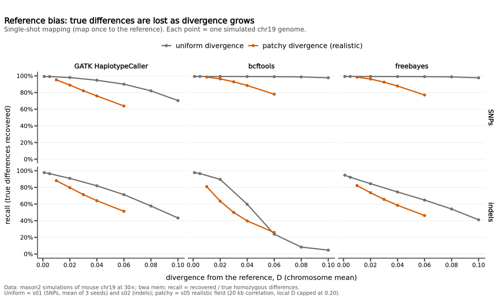

```r
# Single-shot recall vs divergence, by caller (columns) and variant type (rows).
# Uniform: s01 (SNP-only; averaged over seeds 42-44) for SNPs, s02 (SNP + indel) for indels.
# Patchy:  s05 realistic mean-sweep, SNP-only sim for SNPs, SNP + indel sim for indels.
# D = 0 (no divergence -> recall undefined) is excluded.
one_shot <- function(path, recall_fun, scenario, variant) {
  d <- read_csv(path) %>% filter(iteration == 1, divergence > 0)
  d %>% mutate(recall = recall_fun(d)) %>%
    group_by(caller, divergence) %>% summarize(recall = mean(recall), .groups = "drop") %>%
    mutate(scenario = scenario, variant = variant)
}
f1 <- bind_rows(
  one_shot(S01_SUMMARY, snp_recall,   "uniform divergence",            "SNPs"),
  one_shot(S02_SUMMARY, indel_recall, "uniform divergence",            "indels"),
  one_shot(S05_SNP,     snp_recall,   "patchy divergence (realistic)", "SNPs"),
  one_shot(S05_INDEL,   indel_recall, "patchy divergence (realistic)", "indels")) %>%
  mutate(caller = fac(caller),
         scenario = factor(scenario, levels = c("uniform divergence", "patchy divergence (realistic)")),
         variant = factor(variant, levels = c("SNPs", "indels")))

p1 <- ggplot(f1, aes(divergence, recall, colour = scenario)) +
  geom_line(linewidth = 1) + geom_point(size = 1.8) +
  scale_colour_manual(values = c(`uniform divergence` = "grey45",
                                 `patchy divergence (realistic)` = "#D55E00"), name = NULL) +
  scale_x_continuous(breaks = seq(0, 0.10, 0.02)) +
  # full 0-100 % axis: bcftools uniform-divergence indel recall falls below 10 % at D >= 0.08
  scale_y_continuous(labels = pct, limits = c(0, 1), breaks = seq(0, 1, 0.2)) +
  facet_grid(variant ~ caller) +
  labs(title = "Reference bias: true differences are lost as divergence grows",
       subtitle = "Single-shot mapping (map once to the reference). Each point = one simulated chr19 genome.",
       x = "divergence from the reference, D (chromosome mean)",
       y = "recall (true differences recovered)",
       caption = paste("Data: mason2 simulations of mouse chr19 at 30×; bwa mem; recall = recovered / true homozygous differences.",
                       "Uniform = s01 (SNPs, mean of 3 seeds) and s02 (indels); patchy = s05 realistic field (20 kb correlation, local D capped at 0.20).",
                       sep = "\n")) +
  brieftheme()
save_fig(p1, "fig1-problem", 12, 7.2)
```

**How to read it.** Each panel is one caller (columns) and one variant type (rows); lower = more true differences missed. Grey lines: every region is equally diverged; orange lines: the same mean divergence, but concentrated in some regions (what real genomes look like).

**What it shows.**

- All callers lose true differences as D grows; GATK loses the most SNPs (30% missed at D = 0.10, uniform).
- Indels are always recovered worse than SNPs. bcftools is worst on indels and collapses once D passes ~0.04 (uniform: 5% at D = 0.10).
- At the same mean D, the patchy genome loses more than the uniform one in almost every panel. Patchiness itself doesn’t make any region harder (Figure 1B): the patchy genome puts many of its variants in regions far more diverged than the mean, where recall falls steeply. The exception is bcftools indels at D = 0.06, where both are already near the floor (~25 %).

## 1B — Why the patchy genome loses more

SIM DATA — chr19, 30× · single-shot SNP recall · patchy (orange): **s05** realistic field, SNP-only sim, mean D = 0.03, seed 42, all ~1.84 million divergent SNPs binned by local divergence · uniform (grey): **s01** SNP-only sims, mean of 3 seeds

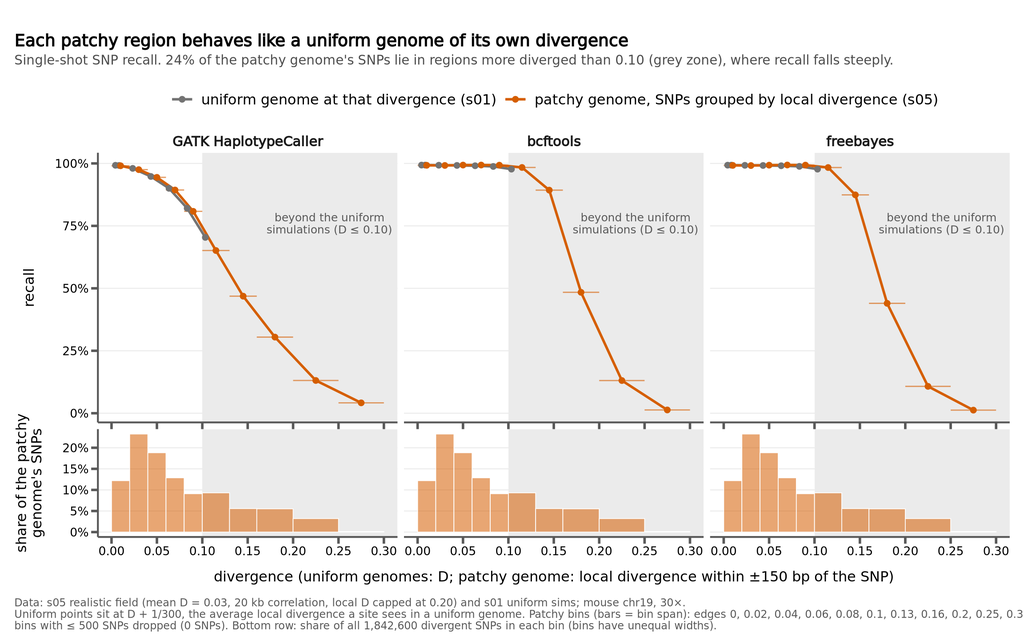

```r
# Is a patchy genome just a mix of regions that each behave like a uniform genome of their own
# divergence? Overlay (a) the patchy genome's recall per local-divergence bin on (b) the uniform
# genomes' recall vs D, and show where the patchy genome's SNPs sit.
loc_all <- read_csv(S05_LOCAL) %>%
  filter(field == PATCHY_FIELD, iteration == 1)
n_patchy <- filter(loc_all, window == "all", caller == "gatk")$n_sites    # all divergent SNPs
stopifnot(length(n_patchy) == 1)
loc_bins <- filter(loc_all, window == as.character(LOCAL_WINDOW))
loc <- filter(loc_bins, n_sites > LOCAL_MIN_SITES)
n_dropped <- sum(filter(loc_bins, caller == "gatk")$n_sites) - sum(filter(loc, caller == "gatk")$n_sites)

# uniform genomes: s01 single-shot SNP recall (mean of 3 seeds), placed at the local divergence a
# site in a uniform genome sees on average, D + 1/(2W) (the window counts the site itself)
unif <- read_csv(S01_SUMMARY) %>% filter(iteration == 1, divergence > 0) %>%
  group_by(caller, divergence) %>% summarize(recall = mean(div_tp / n_truth_div), .groups = "drop") %>%
  mutate(x = divergence + 1 / (2 * LOCAL_WINDOW))
unif_max <- max(unif$x)
stopifnot(LOCAL_SPLIT <= unif_max)                  # the comparison never extrapolates

# share of the patchy genome's SNPs per bin (caller-independent, so taken from the gatk rows)
share <- filter(loc, caller == "gatk") %>% select(locald_lo, locald_hi, n_sites) %>%
  mutate(share = n_sites / n_patchy)

LAB_UNIF   <- "uniform genome at that divergence (s01)"
LAB_PATCHY <- "patchy genome, SNPs grouped by local divergence (s05)"
f1b <- bind_rows(
  transmute(unif, caller, x, y = recall, xmin = NA_real_, xmax = NA_real_, what = LAB_UNIF),
  transmute(loc, caller, x = locald_mid, y = recall, xmin = locald_lo, xmax = locald_hi, what = LAB_PATCHY)) %>%
  mutate(caller = fac(caller), what = factor(what, levels = c(LAB_UNIF, LAB_PATCHY)))
f1b_share <- tidyr::crossing(share, caller = callers) %>% mutate(caller = fac(caller))
beyond <- sum(share$share[share$locald_lo >= LOCAL_SPLIT])
x_max  <- max(loc$locald_hi)

# grey zone: beyond the most diverged uniform simulation (D <= 0.10), so no direct comparison
zone <- tibble(xmin = LOCAL_SPLIT, xmax = Inf, ymin = -Inf, ymax = Inf)
x_scale <- scale_x_continuous(limits = c(0, x_max), breaks = seq(0, 0.3, 0.05))

# top: recall (horizontal bars on the patchy points = the span of each bin)
p1b_top <- ggplot() +
  geom_rect(data = zone, aes(xmin = xmin, xmax = xmax, ymin = ymin, ymax = ymax), fill = "grey92") +
  annotate("text", x = 0.24, y = 0.80, vjust = 1, size = 3.3, colour = "grey35",   # clear of the curves
           lineheight = 0.9, label = sprintf("beyond the uniform\nsimulations (D ≤ %.2f)", LOCAL_SPLIT)) +
  geom_errorbarh(data = filter(f1b, what == LAB_PATCHY),
                 aes(xmin = xmin, xmax = xmax, y = y, colour = what), height = 0, linewidth = 0.5, alpha = 0.6) +
  geom_line(data = f1b, aes(x, y, colour = what), linewidth = 1) +
  geom_point(data = f1b, aes(x, y, colour = what), size = 2) +
  # named values + breaks: colours and legend order fixed by label, not by layer order
  scale_colour_manual(values = setNames(c("grey45", "#D55E00"), c(LAB_UNIF, LAB_PATCHY)),
                      breaks = c(LAB_UNIF, LAB_PATCHY), name = NULL) +
  x_scale + scale_y_continuous(labels = pct) +
  facet_wrap(~caller, nrow = 1) +
  labs(x = NULL, y = "recall") +
  brieftheme() + theme(axis.text.x = element_blank(), plot.margin = margin(5, 5, 0, 5))

# bottom: where the patchy genome's SNPs sit (same x axis, one copy per caller column)
p1b_bot <- ggplot() +
  geom_rect(data = zone, aes(xmin = xmin, xmax = xmax, ymin = ymin, ymax = ymax), fill = "grey92") +
  geom_rect(data = f1b_share, aes(xmin = locald_lo, xmax = locald_hi, ymin = 0, ymax = share),
            fill = "#D55E00", alpha = 0.55, colour = "white", linewidth = 0.3) +
  x_scale + scale_y_continuous(labels = pct) +
  facet_wrap(~caller, nrow = 1) +
  labs(x = "divergence (uniform genomes: D; patchy genome: local divergence within ±150 bp of the SNP)",
       y = "share of the patchy\ngenome's SNPs") +
  brieftheme() + theme(strip.text = element_blank(), plot.margin = margin(0, 5, 5, 5))

p1b <- patchwork::wrap_plots(p1b_top, p1b_bot, ncol = 1, heights = c(3, 1.2)) +
  patchwork::plot_annotation(
    title = "Each patchy region behaves like a uniform genome of its own divergence",
    subtitle = sprintf(paste0("Single-shot SNP recall. %s of the patchy genome's SNPs lie in regions more diverged",
                              " than %.2f (grey zone), where recall falls steeply."), pct(beyond, 1), LOCAL_SPLIT),
    caption = paste0("Data: s05 realistic field (mean D = 0.03, 20 kb correlation, local D capped at 0.20) and s01 uniform sims; mouse chr19, 30×.\n",
                     "Uniform points sit at D + 1/300, the average local divergence a site sees in a uniform genome. Patchy bins (bars = bin span): edges ",
                     paste(sort(unique(c(loc$locald_lo, loc$locald_hi))), collapse = ", "), ";\n",
                     "bins with ≤ ", LOCAL_MIN_SITES, " SNPs dropped (", format(n_dropped, big.mark = ","),
                     " SNPs). Bottom row: share of all ", format(n_patchy, big.mark = ","),
                     " divergent SNPs in each bin (bins have unequal widths)."),
    theme = brieftheme())
save_fig(p1b, "fig1b-local-divergence", 12, 7.5)
```

```r
# observed vs predicted recall for patchy SNPs below LOCAL_SPLIT: predict each bin from the
# uniform curve (linear interpolation at the bin midpoint; never extrapolated), weight by SNPs
predict_unif <- function(cc, xx) {
  u <- filter(unif, caller == cc)
  approx(u$x, u$recall, xout = xx, rule = 1)$y
}
cmp <- loc %>% filter(locald_hi <= LOCAL_SPLIT) %>% rowwise() %>%
  mutate(pred = predict_unif(caller, locald_mid)) %>% ungroup()
stopifnot(!anyNA(cmp$pred))
cmp_sum <- cmp %>% group_by(caller) %>%
  summarize(observed = sum(n_recovered) / sum(n_sites),
            predicted = sum(pred * n_sites) / sum(n_sites), .groups = "drop")
# share of each caller's missed SNPs that sit above LOCAL_SPLIT (from all bins, none dropped)
loss_beyond <- loc_bins %>% group_by(caller) %>%
  summarize(share = sum((n_sites - n_recovered)[locald_lo >= LOCAL_SPLIT]) / sum(n_sites - n_recovered),
            .groups = "drop")
o <- function(cc, col) pct(filter(cmp_sum, caller == cc)[[col]], 0.1)
knitr::kable(transmute(cmp_sum, caller = caller_names[caller],
                       `observed recall` = pct(observed, 0.01), `predicted from uniform genomes` = pct(predicted, 0.01)),
             caption = sprintf("Patchy-genome SNPs at local divergence < %.2f (%s of all its divergent SNPs), single-shot.",
                               LOCAL_SPLIT, pct(1 - beyond, 1)))
```

Patchy-genome SNPs at local divergence < 0.10 (76% of all its divergent SNPs), single-shot.

| caller | observed recall | predicted from uniform genomes |
| --- | --- | --- |
| bcftools | 99.28% | 99.09% |
| freebayes | 99.26% | 99.08% |
| GATK HaplotypeCaller | 93.63% | 92.50% |

**How to read it.** Top row: grey = uniform genomes (the whole chromosome at one divergence, as in Figure 1A); orange = the patchy genome’s SNPs grouped by how diverged their own neighbourhood is. Bottom row: how many of the patchy genome’s SNPs fall in each group. Grey zone: more diverged than any uniform genome we simulated.

**What it shows.**

- Where both exist (local divergence below 0.10), the orange points sit on the grey curve. Predicting the patchy genome’s recall there from the uniform genomes gives 99.1% for bcftools (observed 99.3%) and 92.5% for GATK (observed 93.6%); see the table. Being in a patchy genome doesn’t make a region harder.
- The patchy genome’s extra loss comes from the 24% of its SNPs in regions above 0.10: they account for 92% of bcftools’ missed SNPs and 73% of GATK’s.
- Practical consequence: the genome-wide average divergence is a poor guide to how much is lost. What matters is how much of the genome is highly diverged.
- Caveat: above 0.10 there is no uniform genome to compare with, so the match is shown only below it (uniform sims at D = 0.15–0.20 would close the gap).

# Figure 2 — The fix: iterative mapping

Iterative mapping recovers lost differences for every caller, in both kinds of genome — dramatically for bcftools indels and GATK SNPs, least for freebayes indels.

## 2A — Patchy (realistic) divergence

SIM DATA — chr19, 30× · patchy (realistic) divergence · **s05** SNP-only sim (SNP recall) and SNP + indel sim (indel recall) · seed 42 · iterations 1–3

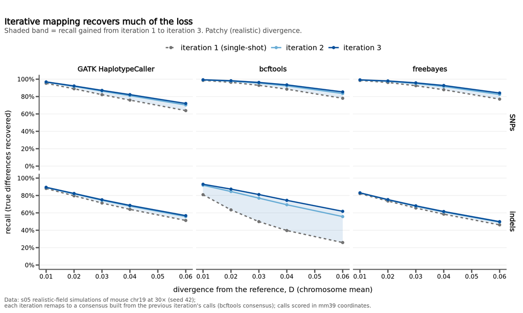

```r
# Recall by iteration, by caller (columns) and variant type (rows). Shared by 2A (patchy) and 2B
# (uniform). The shaded band = recall gained between iteration 1 and iteration 3.
by_iter <- function(path, recall_fun, variant) {
  d <- read_csv(path) %>% filter(divergence > 0)            # D = 0: recall undefined
  d %>% mutate(recall = recall_fun(d)) %>%
    group_by(caller, divergence, iteration) %>%
    summarize(recall = mean(recall), .groups = "drop") %>%   # mean over seeds (s01 has 3; others 1)
    mutate(variant = variant)
}
prep_iter <- function(f) {
  mutate(f, caller = fac(caller), variant = factor(variant, levels = c("SNPs", "indels")),
         iter_lab = factor(iteration, levels = 1:3,
                           labels = c("iteration 1 (single-shot)", "iteration 2", "iteration 3")))
}
gain_band <- function(f) {
  f %>% select(caller, variant, divergence, iteration, recall) %>%
    pivot_wider(names_from = iteration, values_from = recall, names_prefix = "it")
}
fix_plot <- function(f, band, x_breaks, subtitle, caption) {
  ggplot(f, aes(divergence, recall)) +
    geom_ribbon(data = band, aes(x = divergence, ymin = it1, ymax = it3), inherit.aes = FALSE,
                fill = "#2171B5", alpha = 0.13) +
    geom_line(aes(colour = iter_lab, linetype = iter_lab), linewidth = 1) +
    geom_point(aes(colour = iter_lab), size = 1.8) +
    scale_colour_manual(values = c("grey45", "#6BAED6", "#08519C"), name = NULL) +
    scale_linetype_manual(values = c("22", "solid", "solid"), name = NULL) +
    scale_x_continuous(breaks = x_breaks) +
    scale_y_continuous(labels = pct, limits = c(0, 1), breaks = seq(0, 1, 0.2)) +   # same axis as Fig 1
    facet_grid(variant ~ caller) +
    labs(title = "Iterative mapping recovers much of the loss", subtitle = subtitle,
         x = "divergence from the reference, D (chromosome mean)",
         y = "recall (true differences recovered)", caption = caption) +
    brieftheme()
}
CAPTION_ITER <- paste("each iteration remaps to a consensus built from the previous iteration's calls",
                      "(bcftools consensus); calls scored in mm39 coordinates.")

f2 <- prep_iter(bind_rows(by_iter(S05_SNP, snp_recall, "SNPs"),
                          by_iter(S05_INDEL, indel_recall, "indels")))
band <- gain_band(f2)
p2 <- fix_plot(f2, band, seq(0.01, 0.06, 0.01),
               "Shaded band = recall gained from iteration 1 to iteration 3. Patchy (realistic) divergence.",
               paste0("Data: s05 realistic-field simulations of mouse chr19 at 30× (seed 42);\n", CAPTION_ITER))
save_fig(p2, "fig2-fix", 12, 7.2)
```

```r
# the two headline gains quoted in the text, computed from the plotted data
g_bcf_ind <- filter(band, caller == caller_names["bcftools"], variant == "indels", divergence == 0.06)
g_gatk_snp <- filter(band, caller == caller_names["gatk"], variant == "SNPs", divergence == 0.06)
```

**How to read it.** Same layout as Figure 1, patchy scenario only. Dashed grey = single-shot (the orange lines of Figure 1A); dark blue = after 3 iterations.

**What it shows.**

- Every caller improves, and most of the gain comes in the first extra round (iteration 2).
- The biggest rescue is bcftools on indels: at D = 0.06, 26% → 62%. GATK SNPs at D = 0.06: 64% → 72%.
- Iteration does not reach 100 % at high divergence; Figures 3 and 4 show what is left.

## 2B — Uniform divergence

SIM DATA — chr19, 30× · uniform divergence · **s01** SNP-only sim (SNP recall, mean of seeds 42–44) and **s02** SNP + indel sim (indel recall, seed 42) · iterations 1–3

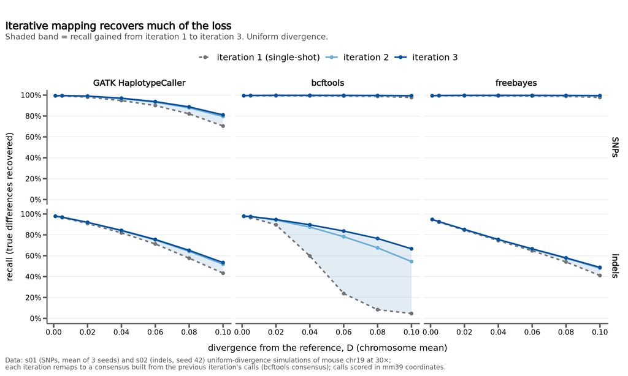

```r
# Same figure on the uniform-divergence sims: s01 (SNP-only, mean of 3 seeds; seed-to-seed SD of
# recall <= ~0.1 point, so no error bars) for SNPs, s02 (SNP + indel) for indels.
f2b <- prep_iter(bind_rows(by_iter(S01_SUMMARY, snp_recall, "SNPs"),
                           by_iter(S02_SUMMARY, indel_recall, "indels")))
band_b <- gain_band(f2b)
p2b <- fix_plot(f2b, band_b, seq(0, 0.10, 0.02),
                "Shaded band = recall gained from iteration 1 to iteration 3. Uniform divergence.",
                paste0("Data: s01 (SNPs, mean of 3 seeds) and s02 (indels, seed 42) uniform-divergence simulations of mouse chr19 at 30×;\n",
                       CAPTION_ITER))
save_fig(p2b, "fig2b-fix-uniform", 12, 7.2)
```

```r
# numbers quoted in the text, at the highest uniform divergence
gb <- function(cc, vv) filter(band_b, caller == caller_names[cc], variant == vv, divergence == 0.10)
```

**How to read it.** Same as 2A, but every region of the chromosome is equally diverged; D runs to 0.10. Dashed grey = the grey lines of Figure 1A.

**What it shows.**

- **SNPs:** bcftools and freebayes already find ~98–99 % single-shot, so there is little to recover. GATK gains the most: 70% → 81% at D = 0.10.
- **Indels:** bcftools goes from almost none to most: 5% → 67% at D = 0.10. GATK gains 10 points. freebayes gains least (41% → 49%): most of its indel loss is not fixed by iteration, in uniform and patchy genomes alike.
- Same pattern as 2A: most of the gain comes at iteration 2.

# Figure 3 — Why: two kinds of failure

A true difference is missed either because the reads carrying it never map to the site (mapping-limited) or because they map but the caller doesn’t call it (calling-limited). Iteration reduces both.

## 3A — Which failure, as local divergence rises

SIM DATA — chr19, 30× · **s05** realistic (patchy) field, SNP-only sim, mean D = 0.03 · seed 42 · read-level ledger on a systematic sample of ~51,000 divergent SNPs (every ~36th along chr19) · iterations 1 and 3

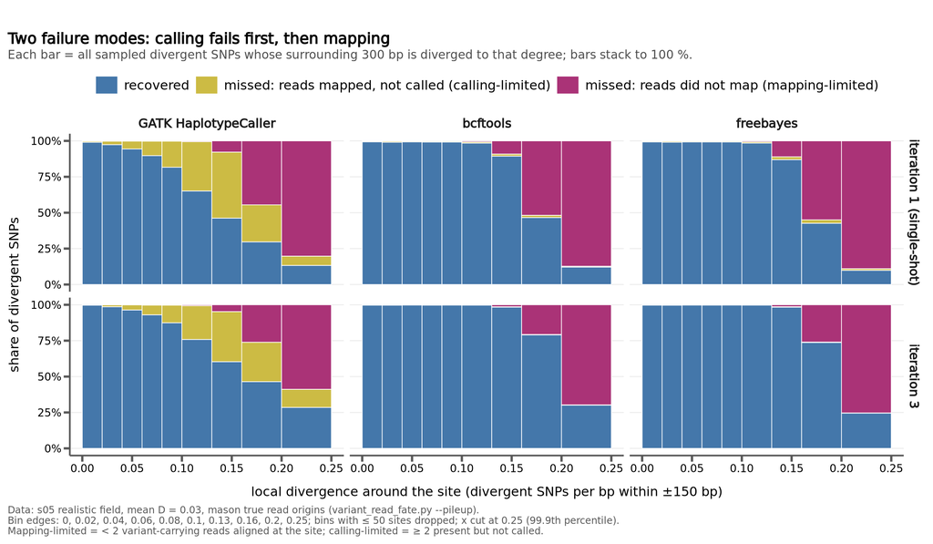

```r
# Share of divergent SNPs in each outcome, binned by LOCAL divergence (divergent truth SNPs per
# bp within +/-150 bp of the site, i.e. what a read covering the site sees). Each bar spans its
# bin; the three outcomes stack to 100 % in each bin.
mvc <- read_csv(S05_MVC) %>%
  filter(window == 150, iteration %in% c(1, 3),
         n_sites > MVC_MIN_SITES, locald_mid <= MVC_MAX_LOCALD)
bin_edges <- sort(unique(c(mvc$locald_lo, mvc$locald_hi)))

f3a <- mvc %>%
  transmute(caller = fac(caller), locald_lo, locald_hi, n_sites,
            iter_lab = factor(paste("iteration", iteration),
                              levels = c("iteration 1", "iteration 3"),
                              labels = c("iteration 1 (single-shot)", "iteration 3")),
            recovered = frac_recovered, `calling-limited` = frac_calling,
            `mapping-limited` = frac_mapping) %>%
  pivot_longer(c(recovered, `calling-limited`, `mapping-limited`),
               names_to = "outcome", values_to = "frac") %>%
  mutate(outcome = factor(outcome, levels = c("recovered", "calling-limited", "mapping-limited"))) %>%
  arrange(caller, iter_lab, locald_lo, outcome) %>%
  group_by(caller, iter_lab, locald_lo) %>%                  # stack: recovered at the bottom
  mutate(ymax = cumsum(frac), ymin = ymax - frac) %>% ungroup()

p3a <- ggplot(f3a) +
  geom_rect(aes(xmin = locald_lo, xmax = locald_hi, ymin = ymin, ymax = ymax, fill = outcome),
            colour = "white", linewidth = 0.3) +
  scale_fill_manual(values = c(recovered = "#4477AA", `calling-limited` = "#CCBB44",
                               `mapping-limited` = "#AA3377"),
                    labels = c(recovered = "recovered",
                               `calling-limited` = "missed: reads mapped, not called (calling-limited)",
                               `mapping-limited` = "missed: reads did not map (mapping-limited)"),
                    name = NULL) +
  scale_x_continuous(breaks = seq(0, 0.25, 0.05)) +
  scale_y_continuous(labels = pct) +
  facet_grid(iter_lab ~ caller) +
  labs(title = "Two failure modes: calling fails first, then mapping",
       subtitle = "Each bar = all sampled divergent SNPs whose surrounding 300 bp is diverged to that degree; bars stack to 100 %.",
       x = "local divergence around the site (divergent SNPs per bp within ±150 bp)",
       y = "share of divergent SNPs",
       caption = paste0("Data: s05 realistic field, mean D = 0.03, mason true read origins (variant_read_fate.py --pileup).\n",
                        "Bin edges: ", paste(bin_edges, collapse = ", "), "; bins with ≤ ", MVC_MIN_SITES,
                        " sites dropped; x cut at ", MVC_MAX_LOCALD, " (99.9th percentile).\n",
                        "Mapping-limited = < 2 variant-carrying reads aligned at the site; calling-limited = ≥ 2 present but not called.")) +
  brieftheme()
save_fig(p3a, "fig3a-mapping-vs-calling", 12, 7)
```

**How to read it.** The x axis is how diverged the immediate neighbourhood of a site is (not the genome mean): in a patchy genome most sites sit below 0.10, a few much higher. Blue = found; yellow and magenta = missed, split by cause. Top row single-shot, bottom row after 3 iterations.

**What it shows.**

- **Calling-limited (yellow)** loss is mostly GATK’s: from moderate local divergence (~0.05) the reads are there but its local re-assembly fails. bcftools and freebayes, which call directly from the aligned reads, barely show it. GATK’s loss concentrates where SNPs cluster (Figure 3E).
- **Mapping-limited (magenta)** loss is a wall for every caller at high local divergence (≳ 0.15): a 150 bp read with that many mismatches no longer aligns.
- **Iteration shrinks both** (bottom row): writing the recovered variants into the reference lowers the effective divergence, so more reads map and GATK’s re-assembly succeeds more often. Example: bcftools in the 0.16–0.20 bin goes from 47% to 79% recovered.

## 3B — One example, site by site

SIM DATA — chr19, 30× · **s02** SNP + indel sim · uniform divergence, D = 0.10 · seed 42 · GATK HaplotypeCaller · all ~6.1 million divergent SNPs on chr19 · iterations 1–3

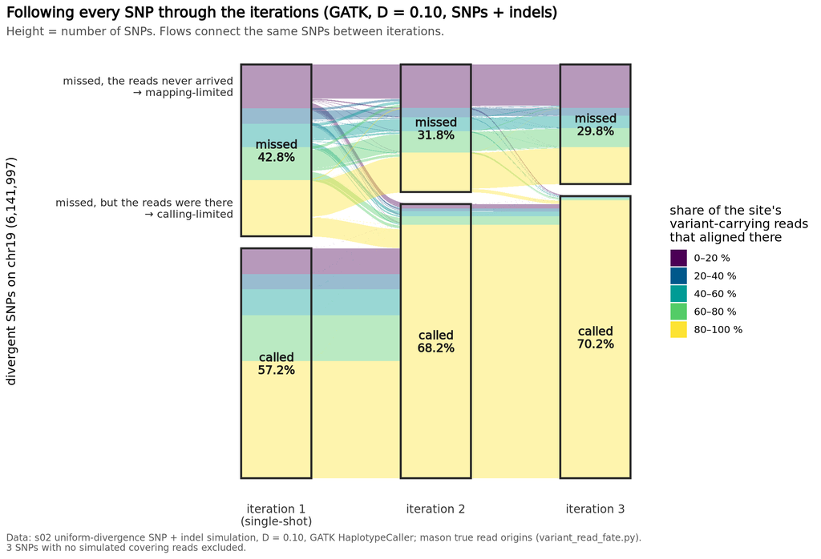

```r
# Per-site flow ("G plot"): every divergent SNP is placed, at each iteration, in the CALLED or
# MISSED box and coloured by how much of its read evidence arrived (f_alt = reads aligned at the
# site showing the alt base / reads that truly carry it, known from mason). Flows link the same
# SNPs across iterations. Input is the aggregated trajectory table from variant_read_fate.py;
# adapted from analyses/lib/vrf_G_figs.R with plain-language labels and band annotations.
BIN      <- c("0.0-0.2", "0.2-0.4", "0.4-0.6", "0.6-0.8", "0.8-1.0")   # f_alt bins, low -> high
BIN_LAB  <- c("0–20 %", "20–40 %", "40–60 %", "60–80 %", "80–100 %")
FB_COL   <- setNames(hcl.colors(length(BIN), "Viridis"), BIN)
GAP_FRAC <- 0.03; BOX_HALFW <- 0.22; STRAT_W <- 0.44; FLOW_A <- 0.4
LEV <- c(paste("missed", BIN, sep = " · "), "gap", paste("called", BIN, sep = " · "))

gt_all <- read_csv(S02_GTRAJ, col_types = cols(divergence = "d", .default = "c")) %>%
  mutate(n_snps = as.numeric(n_snps))
stopifnot(all(gt_all$divergence == G_DIV), all(gt_all$caller == "gatk"))
# sites with no simulated covering read have no f_alt ("nocov"); they are excluded and counted
gt <- filter(gt_all, fb1 %in% BIN, fb2 %in% BIN, fb3 %in% BIN)
n_nocov <- sum(gt_all$n_snps) - sum(gt$n_snps)

lodes <- gt %>% mutate(id = row_number()) %>%
  pivot_longer(c(s1, fb1, s2, fb2, s3, fb3),
               names_to = c(".value", "iter"), names_pattern = "([a-z]+)([0-9])") %>%
  transmute(id, n = n_snps, iter,
            status = ifelse(s == "not_called", "missed", "called"),
            fb = factor(fb, levels = BIN),
            state = factor(paste(status, fb, sep = " · "), levels = LEV), is_gap = FALSE)
gap_n <- round(GAP_FRAC * sum(gt$n_snps))                       # invisible spacer between boxes
lodes <- bind_rows(lodes, tibble(id = max(lodes$id) + 1, n = gap_n, iter = c("1", "2", "3"),
                                 status = "gap", fb = factor(NA, levels = BIN),
                                 state = factor("gap", levels = LEV), is_gap = TRUE))

# outline boxes: CALLED at the bottom, MISSED above the gap (strata stack in LEV order, top down)
box <- lodes %>% filter(!is_gap) %>% group_by(iter, status) %>% summarize(n = sum(n), .groups = "drop") %>%
  group_by(iter) %>% mutate(ncall = sum(n[status == "called"])) %>% ungroup() %>%
  mutate(pos = as.integer(iter), xmin = pos - BOX_HALFW, xmax = pos + BOX_HALFW,
         ymin = ifelse(status == "called", 0, ncall + gap_n),
         ymax = ifelse(status == "called", ncall, ncall + gap_n + n),
         yc = (ymin + ymax) / 2,
         lab = sprintf("%s\n%s", status, pct(n / sum(gt$n_snps), 0.1)))

# annotate the two key bands inside the iteration-1 MISSED box: within a box the bins run from
# 80-100 % at the bottom to 0-20 % at the top, so the bands' y-ranges follow from the counts
b1 <- filter(box, iter == "1", status == "missed")
n_hi <- sum(filter(lodes, iter == "1", status == "missed", fb == "0.8-1.0")$n)
n_lo <- sum(filter(lodes, iter == "1", status == "missed", fb == "0.0-0.2")$n)
ann <- tibble(x = 1 - BOX_HALFW - 0.05,
              y = c(b1$ymin + n_hi / 2, b1$ymax - n_lo / 2),
              lab = c("missed, but the reads were there\n→ calling-limited",
                      "missed, the reads never arrived\n→ mapping-limited"))

p3b <- ggplot(lodes, aes(x = iter, stratum = state, alluvium = id, y = n, fill = fb, alpha = is_gap)) +
  geom_flow() +
  geom_rect(data = box, aes(xmin = xmin, xmax = xmax, ymin = ymin, ymax = ymax),
            inherit.aes = FALSE, fill = "white") +
  geom_stratum(colour = NA, width = STRAT_W) +
  geom_rect(data = box, aes(xmin = xmin, xmax = xmax, ymin = ymin, ymax = ymax),
            inherit.aes = FALSE, fill = NA, colour = "grey15", linewidth = 0.9) +
  geom_text(data = box, aes(x = pos, y = yc, label = lab), inherit.aes = FALSE,
            size = 4, fontface = "bold", colour = "grey10", lineheight = 0.9) +
  geom_text(data = ann, aes(x = x, y = y, label = lab), inherit.aes = FALSE,
            hjust = 1, size = 3.6, colour = "grey15", lineheight = 0.9) +
  scale_alpha_manual(values = c(`FALSE` = FLOW_A, `TRUE` = 0), guide = "none") +
  scale_fill_manual(values = FB_COL, labels = BIN_LAB, limits = BIN, drop = FALSE,
                    na.value = "white", na.translate = FALSE,
                    name = "share of the site's\nvariant-carrying reads\nthat aligned there") +
  scale_x_discrete(labels = c("iteration 1\n(single-shot)", "iteration 2", "iteration 3"),
                   expand = expansion(add = c(1.6, 0.35))) +             # room for the band labels
  labs(title = sprintf("Following every SNP through the iterations (GATK, D = %.2f, SNPs + indels)", G_DIV),
       subtitle = "Height = number of SNPs. Flows connect the same SNPs between iterations.",
       x = NULL, y = sprintf("divergent SNPs on chr19 (%s)", format(sum(gt$n_snps), big.mark = ",")),
       caption = paste0("Data: s02 uniform-divergence SNP + indel simulation, D = ", sprintf("%.2f", G_DIV),
                        ", GATK HaplotypeCaller; mason true read origins (variant_read_fate.py).\n",
                        format(n_nocov, big.mark = ","), " SNPs with no simulated covering reads excluded.")) +
  theme_minimal(base_size = 12) +
  theme(panel.grid = element_blank(), axis.text.y = element_blank(),
        axis.text.x = element_text(size = 11, colour = "grey20"),
        plot.title = element_text(face = "bold", size = 14), plot.title.position = "plot",
        plot.subtitle = element_text(size = 11, colour = "grey30"),
        plot.caption = element_text(hjust = 0, size = 9, colour = "grey35"),
        plot.caption.position = "plot")
save_fig(p3b, "fig3b-per-site-flow", 11, 7.5)
```

```r
# numbers quoted in the text, from the same trajectory table as the panel
tot_n   <- sum(gt$n_snps)
miss1   <- sum(gt$n_snps[gt$s1 == "not_called"]) / tot_n          # missed at iteration 1
miss3   <- sum(gt$n_snps[gt$s3 == "not_called"]) / tot_n          # missed at iteration 3
by_bin1 <- gt %>% filter(s1 == "not_called") %>% group_by(fb1) %>%
  summarize(tot = sum(n_snps), rescued3 = sum(n_snps[s3 == "called"]) / tot, .groups = "drop") %>%
  mutate(share = tot / sum(tot))                                   # share of iteration-1 misses
dark3   <- gt %>% filter(s3 == "not_called") %>%
  summarize(s = sum(n_snps[fb3 == "0.0-0.2"]) / sum(n_snps)) %>% pull(s)
hi <- filter(by_bin1, fb1 == "0.8-1.0"); lo <- filter(by_bin1, fb1 == "0.0-0.2")
```

**How to read it.** Each column is one iteration; the lower box holds the SNPs GATK called, the upper box those it missed (percent = share of all SNPs). Colour = how much of a site’s read evidence reached it: **yellow** = the reads carrying the variant aligned there (so a miss is the caller’s fault), **dark purple** = they didn’t (a mapping failure). Ribbons show where the same SNPs go in the next iteration; a ribbon can change colour when more of a site’s reads map after iteration.

**What it shows.** This is a hard case on purpose (D = 0.10 with indels), so both bands are visible.

- Single-shot GATK misses 43% of the SNPs. Of those misses, 33% are yellow (calling-limited) and 26% dark (mapping-limited); the rest are in between.
- Iteration rescues 39% of the yellow misses by iteration 3 but only 20% of the dark ones (overall misses fall to 30%).
- So dark, mapping-limited sites make up a growing share of what is left (26% of misses at iteration 1, 36% at iteration 3). Here the nearby indels are what stop the reads aligning, and iteration only partly clears them.

## 3C — What changed for the SNPs that iteration rescued

SIM DATA — chr19, 30× · **s02** SNP + indel sim · uniform divergence, D = 0.10 · seed 42 · read-level ledger on a systematic sample of ~30,000 divergent SNPs · consecutive iterations (1 → 2 and 2 → 3, pooled)

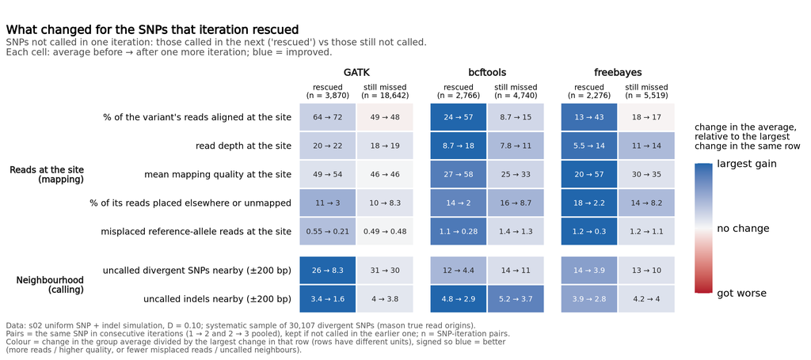

```r
# One summary of the synthesis notebook's per-site "flip" analysis: for SNPs that were NOT called
# in one iteration, what changed by the next iteration -- for those that became called ("rescued")
# versus those that stayed uncalled ("still missed")? Only factors that CAN change between
# iterations are shown (read placement, uncalled neighbourhood); fixed sequence context can't
# change, so the fixed features that matter are shown separately: a nearby indel (Fig 3D) and
# SNP clustering (Fig 3E).

# --- per-site data: read ledger (sample) + uncalled neighbours, every iteration ------------------
pile <- bind_rows(lapply(list.files(FLIP_PILEUP, sprintf("-%s\\.csv$", FLIP_DIV), full.names = TRUE),
                         read_csv, col_types = cols(caller = "c", ref = "c", alt = "c", .default = "d")))
neigh <- read_csv(FLIP_NEIGH, col_types = cols(caller = "c", .default = "d")) %>%
  filter(divergence == as.numeric(FLIP_DIV))
sites <- pile %>%
  left_join(select(neigh, caller, snp_pos, iteration, nb_snp = n_unrecovered, nb_indel = n_unrecovered_indel),
            by = c("caller", "snp_pos", "iteration")) %>%
  filter(n_true_alt > 0) %>%                                   # no simulated covering read: no f_alt
  mutate(f_alt  = 100 * (ex_alt + sh_alt) / n_true_alt,         # % of its variant reads aligned at p
         mm_out = 100 * (mm_clip + mm_noclip + dc + un) / n_true_alt)  # % placed elsewhere / unmapped
stopifnot(!anyNA(select(sites, nb_snp, nb_indel, depth_p, mapq_p)))

# --- factors that change between iterations: column, plain label, direction that is "better" -----
flip_factors <- tribble(
  ~col,         ~label,                                             ~better, ~group,
  "f_alt",      "% of the variant's reads aligned at the site",      +1, "Reads at the site\n(mapping)",
  "depth_p",    "read depth at the site",                            +1, "Reads at the site\n(mapping)",
  "mapq_p",     "mean mapping quality at the site",                  +1, "Reads at the site\n(mapping)",
  "mm_out",     "% of its reads placed elsewhere or unmapped",       -1, "Reads at the site\n(mapping)",
  "mmin_ref_p", "misplaced reference-allele reads at the site",      -1, "Reads at the site\n(mapping)",
  "nb_snp",     "uncalled divergent SNPs nearby (±200 bp)",          -1, "Neighbourhood\n(calling)",
  "nb_indel",   "uncalled indels nearby (±200 bp)",                  -1, "Neighbourhood\n(calling)")

# --- pair each SNP with itself one iteration later; keep SNPs uncalled in the earlier one ---------
pair_iter <- function(k) {
  inner_join(filter(sites, iteration == k) %>% select(caller, snp_pos, recovered, all_of(flip_factors$col)),
             filter(sites, iteration == k + 1) %>% select(caller, snp_pos, recovered, all_of(flip_factors$col)),
             by = c("caller", "snp_pos"), suffix = c("_before", "_after"))
}
all_pairs <- bind_rows(pair_iter(1), pair_iter(2))
flips <- all_pairs %>%
  filter(recovered_before == 0) %>%
  mutate(fate = ifelse(recovered_after == 1, "rescued", "still missed"))

# group means before and after. Colour = change in the mean, oriented so > 0 = improved, scaled by
# the largest absolute change in the same row (factors have different units, so only within-row
# comparison is meaningful): 1 = the biggest improvement seen for that factor.
flip_sum <- flips %>%
  pivot_longer(c(ends_with("_before"), ends_with("_after")) & !starts_with("recovered"),
               names_pattern = "(.+)_(before|after)$", names_to = c("col", "when")) %>%
  group_by(caller, fate, col, when) %>% summarize(m = mean(value), n = n(), .groups = "drop") %>%
  pivot_wider(names_from = when, values_from = m) %>%
  left_join(flip_factors, by = "col") %>%
  mutate(change = better * (after - before)) %>%
  group_by(col) %>% mutate(rel = change / max(abs(change))) %>% ungroup() %>%
  mutate(caller = fac(caller),
         label = factor(label, levels = rev(flip_factors$label)),
         group = factor(group, levels = unique(flip_factors$group)),
         txt = sprintf("%s → %s", signif(before, 2), signif(after, 2)),
         comp = factor(fate, levels = c("rescued", "still missed")))
stopifnot(all(is.finite(flip_sum$rel)))
# one x level per caller x fate so each column header can carry its own SNP count
flip_sum <- mutate(flip_sum, xkey = factor(paste(caller, fate), levels = unique(paste(caller, fate)[order(caller, comp)])))

flip_xlabs <- distinct(flip_sum, xkey, fate, n) %>%
  { setNames(sprintf("%s\n(n = %s)", .$fate, trimws(format(.$n, big.mark = ","))), .$xkey) }

p3c <- ggplot(flip_sum, aes(xkey, label, fill = rel)) +
  geom_tile(colour = "white", linewidth = 0.8) +
  geom_text(aes(label = txt, colour = abs(rel) > 0.55), size = 3.1) +
  scale_colour_manual(values = c(`TRUE` = "white", `FALSE` = "grey15"), guide = "none") +
  scale_fill_gradient2(low = "#B2182B", mid = "grey97", high = "#2166AC", midpoint = 0,
                       limits = c(-1, 1), breaks = c(-1, 0, 1),
                       labels = c("got worse", "no change", "largest gain"),
                       name = "change in the average,\nrelative to the largest\nchange in the same row") +
  guides(fill = guide_colourbar(barheight = unit(5.5, "cm"), title.theme = element_text(size = 10.5, margin = margin(b = 16)))) +
  scale_x_discrete(labels = flip_xlabs, position = "top") +
  facet_grid(group ~ caller, scales = "free", space = "free", switch = "y",
             labeller = labeller(caller = c(`GATK HaplotypeCaller` = "GATK", bcftools = "bcftools",
                                            freebayes = "freebayes"))) +
  labs(title = "What changed for the SNPs that iteration rescued",
       subtitle = paste("SNPs not called in one iteration: those called in the next ('rescued') vs those still not called.",
                        "Each cell: average before → after one more iteration; blue = improved.", sep = "\n"),
       x = NULL, y = NULL,
       caption = paste0("Data: s02 uniform SNP + indel simulation, D = ", FLIP_DIV, "; systematic sample of ",
                        format(n_distinct(sites$snp_pos), big.mark = ","), " divergent SNPs (mason true read origins).\n",
                        "Pairs = the same SNP in consecutive iterations (1 → 2 and 2 → 3 pooled), kept if not called in the earlier one; ",
                        "n = SNP-iteration pairs.\n",
                        "Colour = change in the group average divided by the largest change in that row (rows have different units), ",
                        "signed so blue = better\n(more reads / higher quality, or fewer misplaced reads / uncalled neighbours).")) +
  brieftheme() +
  theme(axis.text.x.top = element_text(size = 9, lineheight = 0.9), axis.text.y = element_text(size = 10.5),
        axis.line = element_blank(), axis.ticks = element_blank(), panel.grid.major.y = element_blank(),
        strip.placement = "outside", strip.text.y.left = element_text(angle = 0, hjust = 1, size = 10.5),
        legend.position = "right")
save_fig(p3c, "fig3c-what-changed", 13.5, 6)
```

```r
# values quoted in the text
fv <- function(cc, ff, cl) filter(flip_sum, caller == caller_names[cc], fate == ff, col == cl)
fx <- function(cc, ff, cl) { r <- fv(cc, ff, cl); sprintf("%s → %s", signif(r$before, 2), signif(r$after, 2)) }
```

**How to read it.** Each row is something that can change when a SNP is re-mapped against an updated reference. For each caller, the left column follows SNPs that were missed and then called one iteration later; the right column follows SNPs that were missed and stayed missed. Each cell gives the group’s average before → after that iteration. Blue means it got better (more of the variant’s reads, higher quality, fewer misplaced reads or uncalled neighbours). Because each row has its own units, the colour is relative within a row: the darkest cell in a row is the biggest change seen for that factor; grey means little change. Fixed features of the site (sequence context) can’t change between iterations, so they aren’t in this figure; the ones that matter are a nearby indel (Figure 3D) and SNP clustering (Figure 3E).

**What it shows.**

- **GATK’s rescued SNPs were rescued by their neighbourhood.** Uncalled SNPs nearby fell 26 → 8.3 (still-missed: 31 → 30), and uncalled indels nearby 3.4 → 1.6. Their reads changed much less (64 → 72 % of variant reads aligned), because they were mostly there already. Once the surrounding variants are in the reference, GATK’s local re-assembly works.
- **bcftools’ and freebayes’ rescued SNPs were rescued by their reads.** The share of variant reads aligned at the site went 24 → 57 % (bcftools) and 13 → 43 % (freebayes), and mapping quality 27 → 58 and 20 → 57. Their neighbourhood cleared as well, as the neighbours’ reads also started mapping.
- **Still-missed SNPs change much less**, for every caller. For GATK almost nothing moves, including the neighbourhood (31 → 30 uncalled SNPs nearby). For bcftools their reads improve somewhat (8.7 → 15 % aligned) but not enough to be called. For freebayes the uncalled indels nearby barely clear (4.2 → 4), in line with its indels improving least (Figure 2B).
- The same split holds in the SNP-only simulation (s01) and the synthesis notebook’s per-divergence figures; this is their summary at D = 0.10.

## 3D — Closeness to an indel and rescue

SIM DATA — chr19, 30× · **s02** SNP + indel sim · uniform divergence, D = 0.10 · seed 42 · same SNP-iteration pairs as Figure 3C · distance from each divergent SNP to the nearest truth indel

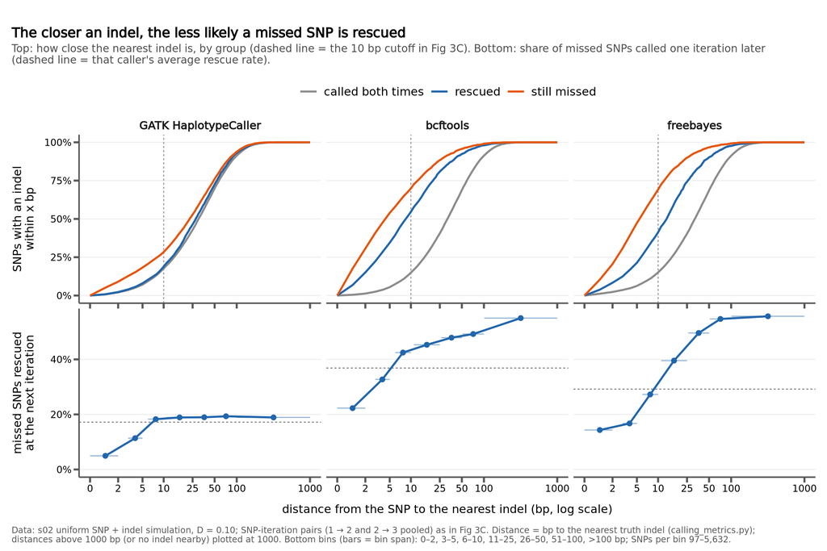

```r
# The fixed-context row of Fig 3C in full: (top) how close the nearest indel is, for SNPs called
# both times / rescued / still missed; (bottom) the rescue rate -- share of missed SNPs called one
# iteration later -- by distance to the nearest indel. Same SNP-iteration pairs as Fig 3C
# (all_pairs / flips from the fig3c chunk), joined to their fixed sequence context.

# fixed context (calling_metrics.py, per divergent SNP): distance to the nearest truth indel, etc.
cmet_flip <- read_csv(sprintf(FLIP_CALLMET, FLIP_DIV), col_types = cols(.default = "d")) %>%
  select(snp_pos, dist_to_indel, indel_density, homopolymer_frac, snp_density, het_density)
near <- function(df) {
  out <- left_join(df, cmet_flip, by = "snp_pos")
  stopifnot(!anyNA(out$dist_to_indel))
  out
}
flips_ctx <- near(flips)
ctx_pairs <- bind_rows(
  mutate(near(filter(all_pairs, recovered_before == 1, recovered_after == 1)), fate = "called both times"),
  flips_ctx) %>%
  mutate(dist = pmin(dist_to_indel, DIST_MAX))            # no indel within DIST_MAX bp -> plotted at DIST_MAX
stopifnot(all(ctx_pairs$dist >= 0))
FATE_LEV <- c("called both times", "rescued", "still missed")
FATE_COL <- c(`called both times` = "grey55", rescued = "#2166AC", `still missed` = "#E6550D")

# top: cumulative share of each group's SNPs with an indel within x bp
grid_x <- c(0:100, seq(110, DIST_MAX, 10))
cum <- ctx_pairs %>% group_by(caller, fate) %>%
  group_modify(function(df, key) tibble(x = grid_x, share = ecdf(df$dist)(grid_x))) %>% ungroup() %>%
  mutate(caller = fac(caller), fate = factor(fate, levels = FATE_LEV))

# bottom: rescue rate by distance bin, among SNPs missed in the earlier iteration
rate <- flips_ctx %>%
  mutate(bin = cut(dist_to_indel, DIST_BINS, labels = DIST_LABS)) %>%
  group_by(caller, bin) %>% summarize(n = n(), rescue = mean(fate == "rescued"), .groups = "drop") %>%
  mutate(lo = DIST_BINS[as.integer(bin)] + 1, hi = pmin(DIST_BINS[as.integer(bin) + 1], DIST_MAX),
         mid = sqrt(pmax(lo, 0.5) * hi), caller = fac(caller))
stopifnot(!anyNA(rate$bin))
overall <- flips_ctx %>% group_by(caller) %>% summarize(rescue = mean(fate == "rescued"), .groups = "drop") %>%
  mutate(caller = fac(caller))

x_d <- scale_x_continuous(trans = scales::pseudo_log_trans(base = 10), limits = c(0, DIST_MAX),
                          breaks = c(0, 2, 5, 10, 25, 50, 100, 1000))
p3d_top <- ggplot(cum, aes(x, share, colour = fate)) +
  geom_vline(xintercept = INDEL_NEAR_BP, linetype = "22", colour = "grey60") +
  geom_line(linewidth = 1) +
  scale_colour_manual(values = FATE_COL, name = NULL) +
  x_d + scale_y_continuous(labels = pct, limits = c(0, 1)) +
  facet_wrap(~caller, nrow = 1) +
  labs(x = NULL, y = "SNPs with an indel\nwithin x bp") +
  brieftheme() + theme(axis.text.x = element_blank(), plot.margin = margin(5, 5, 0, 5))
p3d_bot <- ggplot(rate) +
  geom_hline(data = overall, aes(yintercept = rescue), linetype = "22", colour = "grey50") +
  geom_errorbarh(aes(xmin = lo, xmax = hi, y = rescue), height = 0, colour = "#2166AC", alpha = 0.5) +
  geom_line(aes(mid, rescue), colour = "#2166AC", linewidth = 1) +
  geom_point(aes(mid, rescue), colour = "#2166AC", size = 2.2) +
  x_d + scale_y_continuous(labels = pct, limits = c(0, NA)) +
  facet_wrap(~caller, nrow = 1) +
  labs(x = "distance from the SNP to the nearest indel (bp, log scale)",
       y = "missed SNPs rescued\nat the next iteration") +
  brieftheme() + theme(strip.text = element_blank(), plot.margin = margin(0, 5, 5, 5))

p3d <- patchwork::wrap_plots(p3d_top, p3d_bot, ncol = 1, heights = c(1, 1)) +
  patchwork::plot_annotation(
    title = "The closer an indel, the less likely a missed SNP is rescued",
    subtitle = paste0("Top: how close the nearest indel is, by group (dashed line = the ", INDEL_NEAR_BP,
                      " bp cutoff in Fig 3C). Bottom: share of missed SNPs called one iteration later\n",
                      "(dashed line = that caller's average rescue rate)."),
    caption = paste0("Data: s02 uniform SNP + indel simulation, D = ", FLIP_DIV, "; SNP-iteration pairs (1 → 2 and 2 → 3 pooled) as in Fig 3C. ",
                     "Distance = bp to the nearest truth indel (calling_metrics.py);\n",
                     "distances above ", DIST_MAX, " bp (or no indel nearby) plotted at ", DIST_MAX, ". Bottom bins (bars = bin span): ",
                     paste(DIST_LABS, collapse = ", "), " bp; SNPs per bin ",
                     format(min(rate$n), big.mark = ","), "–", format(max(rate$n), big.mark = ","), "."),
    theme = brieftheme())
save_fig(p3d, "fig3d-indel-distance", 12, 8)
```

```r
# values quoted in the text
rr <- function(cc, b) pct(filter(rate, caller == caller_names[cc], bin == b)$rescue, 1)
med <- ctx_pairs %>% group_by(caller, fate) %>% summarize(m = median(dist), .groups = "drop")
md <- function(cc, ff) filter(med, caller == cc, fate == ff)$m
# number of indels within +/-100 bp, holding the nearest indel > INDEL_NEAR_BP bp away
MANY_INDELS <- 4
cnt <- flips_ctx %>% filter(dist_to_indel > INDEL_NEAR_BP) %>%
  mutate(many = round(indel_density * 200) >= MANY_INDELS) %>%        # density is per bp over 200 bp
  group_by(caller, many) %>% summarize(rescue = mean(fate == "rescued"), n = n(), .groups = "drop")
cr <- function(cc, m) pct(filter(cnt, caller == cc, many == m)$rescue, 1)
# the other fixed factors, for the one-line "they don't differ" statement (all three groups)
homo <- ctx_pairs %>% group_by(caller, fate) %>% summarize(h = mean(homopolymer_frac), .groups = "drop")
homo_rng <- function(cc) pct(range(filter(homo, caller == cc)$h), 0.1)
```

**How to read it.** Both rows share the same x axis: distance from the SNP to the nearest indel, on a log scale. *Top:* for each group of SNPs, the share whose nearest indel is within *x* bp; a curve that rises early means that group’s SNPs sit close to indels. *Bottom:* of the SNPs missed in one iteration, the share called in the next, for SNPs at each distance.

**What it shows.**

- **bcftools and freebayes:** still-missed SNPs sit right next to indels (median nearest indel 5 and 6 bp), rescued ones a little further (9 and 14 bp), and SNPs called both times much further (32 bp). The rescue rate climbs with distance: bcftools 22% with an indel within 2 bp, 42% at 6–10 bp, 55% beyond 100 bp (freebayes 14%, 27%, 56%).
- **GATK:** only an indel within a few bp hurts (rescue 5% at 0–2 bp, 11% at 3–5 bp); beyond ~10 bp its rescue rate is flat at about 19%, because its stuck SNPs are mostly held back by the uncalled neighbourhood instead (Figure 3C).
- The number of indels nearby matters less than the closest one (not plotted). Taking only SNPs whose nearest indel is more than 10 bp away, the rescue rate with fewer than 4 indels within ±100 bp vs 4 or more is 51% vs 39% for bcftools, 50% vs 35% for freebayes, and 19% vs 19% for GATK.
- Of the fixed features measured over ±100 bp around each SNP (`calling_metrics.py`), closeness to an indel is the only one that separates the groups. The others barely differ between SNPs called both times, rescued and still missed (homopolymer fraction 3.2%–4.0% for GATK, 3.4%–3.5% for bcftools), so they aren’t shown. At a finer scale, SNP clustering does matter for GATK (Figure 3E).

## 3E — SNP clusters and GATK

SIM DATA — chr19, 30× · **s01** SNP-only sim · uniform divergence, D = 0.10 · seeds 42–44 pooled · every divergent SNP (no sampling) · iterations 1 and 3

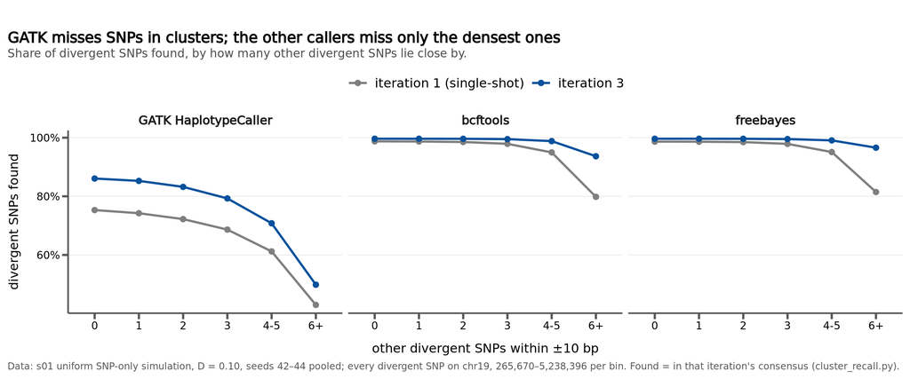

```r
# Recall of divergent SNPs by how many OTHER divergent SNPs lie within +/-CLUSTER_W bp of each one
# (cluster_recall.py; bins 0 / 1 / 2 / 3 / 4-5 / 6+, the last open-ended). Uniform divergence, so the
# count varies only by chance. Found = the SNP is in that iteration's recovered (consensus) set.
CL_BINS <- c("0", "1", "2", "3", "4-5", "6+")
clus <- read_csv(S01_CLUSTER, col_types = cols(divergence = col_character(), n_near_bin = col_character())) %>%
  filter(divergence == CLUSTER_DIV, window_bp == CLUSTER_W, iteration %in% CLUSTER_ITERS) %>%
  group_by(caller, iteration, n_near_bin) %>%                         # pool the seeds
  summarize(n_sites = sum(n_sites), n_recovered = sum(n_recovered), .groups = "drop") %>%
  mutate(recall = n_recovered / n_sites, caller = fac(caller),
         n_near_bin = factor(n_near_bin, levels = CL_BINS),
         iter_lab = factor(iteration, levels = CLUSTER_ITERS, labels = c("iteration 1 (single-shot)", "iteration 3")))
stopifnot(nrow(clus) == length(callers) * length(CLUSTER_ITERS) * length(CL_BINS), !anyNA(clus$n_near_bin))
# share of divergent SNPs per bin (the same for every caller and iteration; taken from GATK iteration 1)
clus_share <- filter(clus, caller == caller_names["gatk"], iteration == 1) %>% mutate(share = n_sites / sum(n_sites))

p3e <- ggplot(clus, aes(n_near_bin, recall, colour = iter_lab, group = iter_lab)) +
  geom_line(linewidth = 1) + geom_point(size = 2.2) +
  scale_colour_manual(values = c("grey50", "#08519C"), name = NULL) +
  scale_y_continuous(labels = pct) +
  facet_wrap(~caller, nrow = 1) +
  labs(x = paste0("other divergent SNPs within ±", CLUSTER_W, " bp"), y = "divergent SNPs found",
       title = "GATK misses SNPs in clusters; the other callers miss only the densest ones",
       subtitle = "Share of divergent SNPs found, by how many other divergent SNPs lie close by.",
       caption = paste0("Data: s01 uniform SNP-only simulation, D = ", CLUSTER_DIV, ", seeds 42–44 pooled; every divergent SNP on chr19, ",
                        format(min(clus_share$n_sites), big.mark = ","), "–", format(max(clus_share$n_sites), big.mark = ","),
                        " per bin. Found = in that iteration's consensus (cluster_recall.py).")) +
  brieftheme()
save_fig(p3e, "fig3e-snp-clusters", 12, 5)
```

```r
# values quoted in the text
cl3 <- function(cc, k, b) pct(filter(clus, caller == caller_names[cc], iteration == k, n_near_bin == b)$recall, 1)
sh3 <- function(b) pct(sum(filter(clus_share, n_near_bin %in% b)$share), 1)
```

**How to read it.** For each divergent SNP, the x axis counts the other divergent SNPs within ±10 bp. In a uniform genome that count varies only by chance: at D = 0.10, 11% of SNPs have none and 15% have four or more. Grey = single-shot, blue = after 3 iterations.

**What it shows.**

- **GATK** finds fewer SNPs the more they cluster: 75% of SNPs with no close neighbour but 43% of those with six or more. Iteration lifts every bin but keeps the gap (86% vs 50%). Its re-assembly is built from short stretches of sequence shared with the reference, and close-packed SNPs leave few of them, which fits the calling-limited loss in Figure 3A being GATK’s.
- **bcftools and freebayes**, which call from the aligned reads, stay at 95% or more until the densest bin (80% and 81%), and iteration repairs that bin (94% and 97%).

# Figure 4 — The limits

Iteration fixes loss caused by the sample’s divergence. It cannot fix loss caused by the reference itself (repeats, structural variants), and filtering the calls can’t recover any loss.

## 4A — Repetitive reference sequence

SIM DATA — chr19, 30× · **s08** = **s01** SNP-only calls (seed 42), uniform divergence D = 0.06, stratified by reference mappability (GenMap, 100-mers, ≤ 2 mismatches)

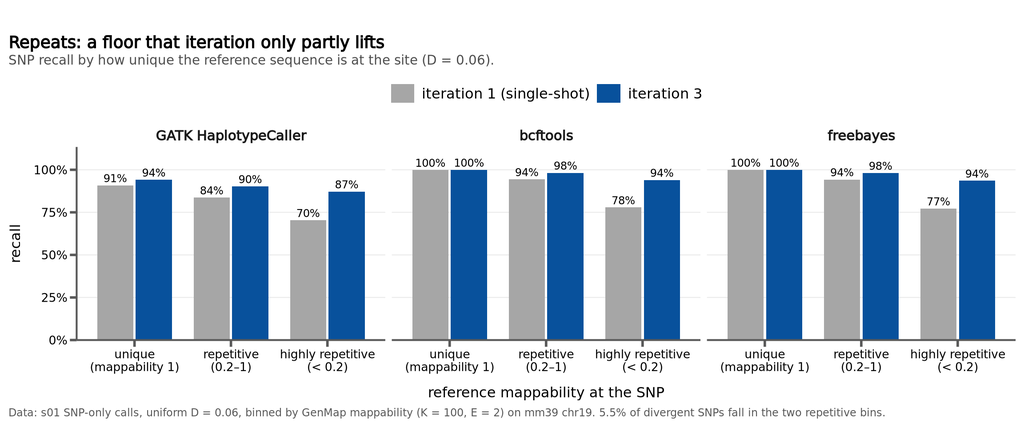

```r
# SNP recall by reference mappability bin, iteration 1 vs 3, at one divergence (MAP_DIV).
# Mappability = GenMap value of the 100-mer starting at the SNP (1 = unique; <0.2 ~ >= 5 copies).
f4a <- read_csv(S08_MAP) %>%
  filter(divergence == MAP_DIV, iteration %in% c(1, 3)) %>%
  mutate(caller = fac(caller),
         map_bin = factor(map_bin, levels = c("unique (1.0)", "repetitive (0.2-1.0)", "highly repetitive (<0.2)"),
                          labels = c("unique\n(mappability 1)", "repetitive\n(0.2–1)", "highly repetitive\n(< 0.2)")),
         iter_lab = factor(iteration, levels = c(1, 3), labels = c("iteration 1 (single-shot)", "iteration 3")))
share_rep <- f4a %>% filter(caller == caller_names["gatk"], iteration == 1) %>%
  summarize(s = sum(n_sites[map_bin != levels(map_bin)[1]]) / sum(n_sites)) %>% pull(s)

p4a <- ggplot(f4a, aes(map_bin, recall, fill = iter_lab)) +
  geom_col(position = position_dodge(width = 0.8), width = 0.75) +
  geom_text(aes(label = scales::percent(recall, 1)), position = position_dodge(width = 0.8),
            vjust = -0.4, size = 3.2) +
  scale_fill_manual(values = c("grey65", "#08519C"), name = NULL) +
  scale_y_continuous(labels = pct, breaks = seq(0, 1, 0.25), expand = expansion(mult = c(0, 0.08))) +
  coord_cartesian(ylim = c(0, 1.05)) +
  facet_wrap(~caller, nrow = 1) +
  labs(title = "Repeats: a floor that iteration only partly lifts",
       subtitle = sprintf("SNP recall by how unique the reference sequence is at the site (D = %.2f).", MAP_DIV),
       x = "reference mappability at the SNP", y = "recall",
       caption = sprintf(paste("Data: s01 SNP-only calls, uniform D = %.2f, binned by GenMap mappability (K = 100, E = 2) on mm39 chr19.",
                               "%s of divergent SNPs fall in the two repetitive bins."), MAP_DIV, pct(share_rep, 0.1))) +
  brieftheme()
save_fig(p4a, "fig4a-repeats", 12, 5)
```

**What it shows.** In unique sequence bcftools and freebayes recover essentially everything. In repetitive sequence reads can’t be placed uniquely (low mapping quality, then dropped), so recall is lower for every caller; iteration helps but leaves a gap. GATK is lower everywhere because of its calling-limited loss (Figure 3). The same pattern holds at D = 0.02 and 0.10 (synthesis notebook).

## 4B — Structural variants

SIM DATA — chr19, 30× · **s07** · ~1,000 SVs (50–5,000 bp; half deletions, half insertions) on a uniform SNP + indel background, D = 0.02 · seed 42 · iterations 1 and 3

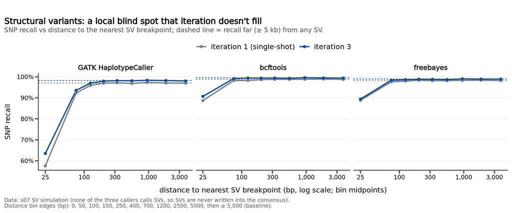

```r
# SNP recall vs distance to the nearest SV breakpoint (deletions: both ends; insertions: the
# anchor). The last distance bin (>= 5 kb) is the SV-free baseline and is drawn as a dashed line.
sv <- read_csv(S07_SV) %>%
  filter(vtype == "snp", bptype == "any", iteration %in% SV_ITERS) %>%
  mutate(caller = fac(caller),
         iter_lab = factor(iteration, levels = SV_ITERS, labels = c("iteration 1 (single-shot)", "iteration 3")))
sv_near <- filter(sv, dist_hi != -1)
sv_base <- filter(sv, dist_hi == -1)
sv_edges <- sort(unique(c(sv_near$dist_lo, sv_near$dist_hi)))

p4b <- ggplot(sv_near, aes(dist_mid, recall, colour = iter_lab)) +
  geom_hline(data = sv_base, aes(yintercept = recall, colour = iter_lab), linetype = "22", linewidth = 0.6) +
  geom_line(linewidth = 1) + geom_point(size = 1.8) +
  scale_colour_manual(values = c("grey50", "#08519C"), name = NULL) +
  scale_x_log10(breaks = c(25, 100, 300, 1000, 3000), labels = scales::comma) +
  scale_y_continuous(labels = pct) +
  facet_wrap(~caller, nrow = 1) +
  labs(title = "Structural variants: a local blind spot that iteration doesn't fill",
       subtitle = "SNP recall vs distance to the nearest SV breakpoint; dashed line = recall far (≥ 5 kb) from any SV.",
       x = "distance to nearest SV breakpoint (bp, log scale; bin midpoints)", y = "SNP recall",
       caption = paste0("Data: s07 SV simulation (none of the three callers calls SVs, so SVs are never written into the consensus).\n",
                        "Distance bin edges (bp): ", paste(sv_edges, collapse = ", "), ", then ≥ 5,000 (baseline).")) +
  brieftheme()
save_fig(p4b, "fig4b-svs", 12, 5)
```

**What it shows.** None of these callers detects SVs, so the SVs themselves are never found and never written into the consensus. Within ~50 bp of a breakpoint SNP recall drops sharply (GATK 58% vs 97% far away), and iteration barely changes it.

## 4C — Filtering the calls

SIM DATA — chr19, 30× · **s06** = hard-filter sweep on the **s01** SNP-only single-shot (iteration 1) calls · uniform divergence D = 0.02–0.10 · seed 42

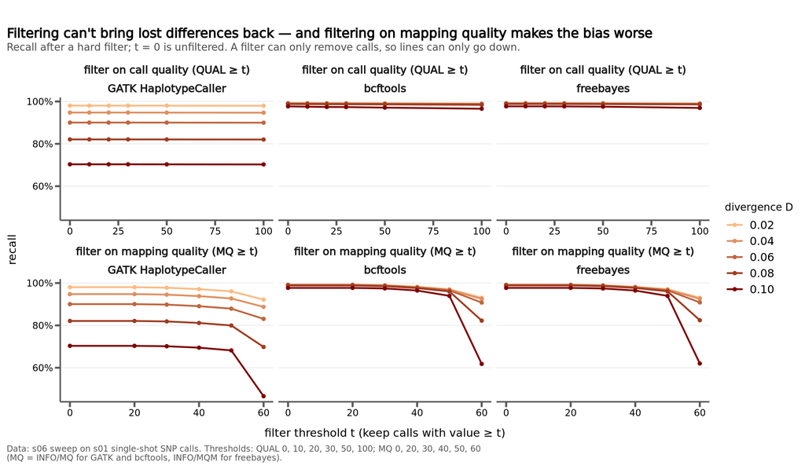

```r
# Recall after keeping only calls with QUAL >= t (top) or mapping quality >= t (bottom;
# INFO/MQ for GATK and bcftools, INFO/MQM for freebayes). t = 0 is unfiltered.
f4c <- read_csv(S06_SWEEP) %>%
  filter(vtype == "snp", axis %in% c("QUAL", "MQ")) %>%
  mutate(caller = fac(caller),
         axis = factor(axis, levels = c("QUAL", "MQ"),
                       labels = c("filter on call quality (QUAL ≥ t)", "filter on mapping quality (MQ ≥ t)")),
         divergence = factor(sprintf("%.2f", divergence)))
div_cols <- scales::seq_gradient_pal("#FDBB84", "#7F0000")(seq(0, 1, length.out = nlevels(f4c$divergence)))

p4c <- ggplot(f4c, aes(threshold, recall, colour = divergence)) +
  geom_line(linewidth = 0.9) + geom_point(size = 1.5) +
  scale_colour_manual(values = div_cols, name = "divergence D") +
  scale_y_continuous(labels = pct) +
  # facet_wrap (not facet_grid) so each ROW gets its own x range: QUAL runs to 100, MQ to 60
  facet_wrap(vars(axis, caller), nrow = 2, scales = "free_x") +
  labs(title = "Filtering can't bring lost differences back — and filtering on mapping quality makes the bias worse",
       subtitle = "Recall after a hard filter; t = 0 is unfiltered. A filter can only remove calls, so lines can only go down.",
       x = "filter threshold t (keep calls with value ≥ t)", y = "recall",
       caption = paste("Data: s06 sweep on s01 single-shot SNP calls. Thresholds: QUAL 0, 10, 20, 30, 50, 100; MQ 0, 20, 30, 40, 50, 60",
                       "(MQ = INFO/MQ for GATK and bcftools, INFO/MQM for freebayes).", sep = "\n")) +
  brieftheme() + theme(legend.position = "right")
save_fig(p4c, "fig4c-filtering", 12, 7)
```

```r
# the MQ >= 60 cost quoted in the text, per divergence, for bcftools
mq_cost <- read_csv(S06_SWEEP) %>%
  filter(vtype == "snp", axis == "MQ", caller == "bcftools", threshold %in% c(0, 60)) %>%
  select(divergence, threshold, recall) %>%
  pivot_wider(names_from = threshold, values_from = recall, names_prefix = "t") %>%
  mutate(cost = t0 - t60)
```

**What it shows.**

- **Top row:** call-quality filters leave recall almost unchanged, because the missing differences were never called in the first place; the gap between the colours (divergence) is untouched. (These filters do raise precision, mainly by removing freebayes false calls.)
- **Bottom row:** mapping-quality filters *widen* the gap. Reads from diverged regions map with lower quality, so the filter preferentially removes the hardest-won calls: MQ ≥ 60 costs bcftools 6.2 recall points at D = 0.02 but 35.9 points at D = 0.10.

# Take-aways

- **Reference bias is real and caller-dependent**; it is worse for indels and for realistic, patchy divergence than a uniform SNP-only simulation suggests.
- **Iterative mapping works** for all three callers, and it works because it lowers the sample’s effective divergence, which helps both reads mapping and the caller calling.
- **What’s left is mostly about the reference** (repeats, SVs), not the sample; iteration can’t fix that, and **hard filters only make it worse** (mapping quality) or leave it unchanged.

# Figure files

Every figure above is also saved, at 300 dpi PNG and as vector PDF, in `analyses/synthesis/figures/brief/` (rewritten each time this notebook is rendered):

| figure | file | source |
| --- | --- | --- |
| 1A | fig1-problem.png / .pdf | s01, s02, s05 summaries |
| 1B | fig1b-local-divergence.png / .pdf | s05 realistic local recall + s01 summary |
| 2A | fig2-fix.png / .pdf | s05 summaries |
| 2B | fig2b-fix-uniform.png / .pdf | s01, s02 summaries |
| 3A | fig3a-mapping-vs-calling.png / .pdf | s05 mapping-vs-calling (capped) |
| 3B | fig3b-per-site-flow.png / .pdf | s02 vrf-agg gatk D = 0.10 |
| 3C | fig3c-what-changed.png / .pdf | s02 vrf-pileup + neighborhood, D = 0.10 |
| 3D | fig3d-indel-distance.png / .pdf | s02 vrf-pileup + calling-metrics, D = 0.10 |
| 3E | fig3e-snp-clusters.png / .pdf | s01 cluster recall, D = 0.10 |
| 4A | fig4a-repeats.png / .pdf | s08 mappability |
| 4B | fig4b-svs.png / .pdf | s07 SV confounder |
| 4C | fig4c-filtering.png / .pdf | s06 filter sweep |